# Binary Classification Model for MiniBooNE Particle Identification Using R Take 3

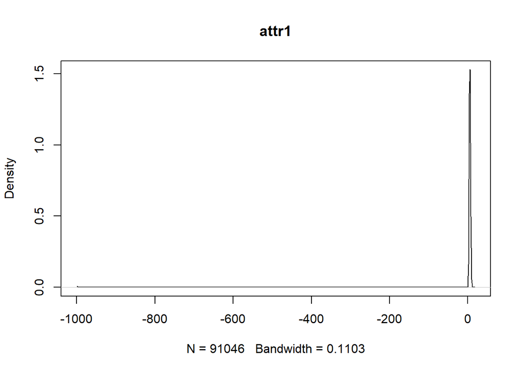

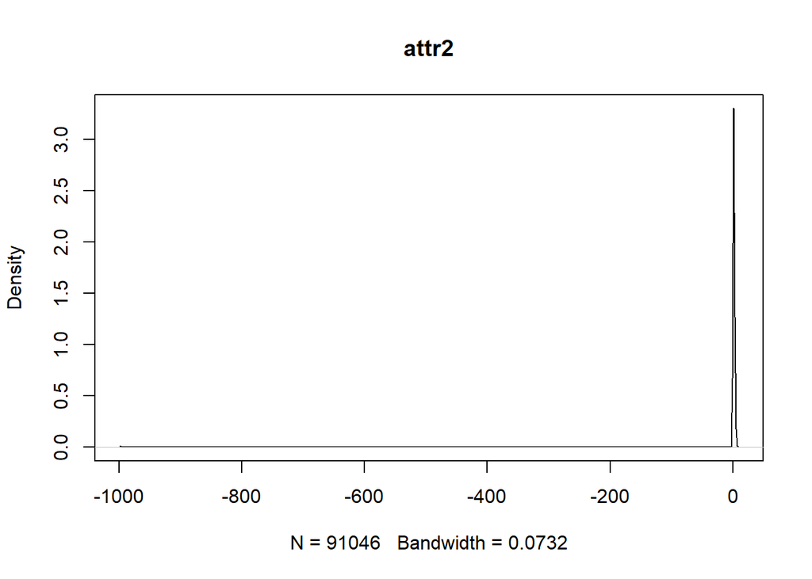

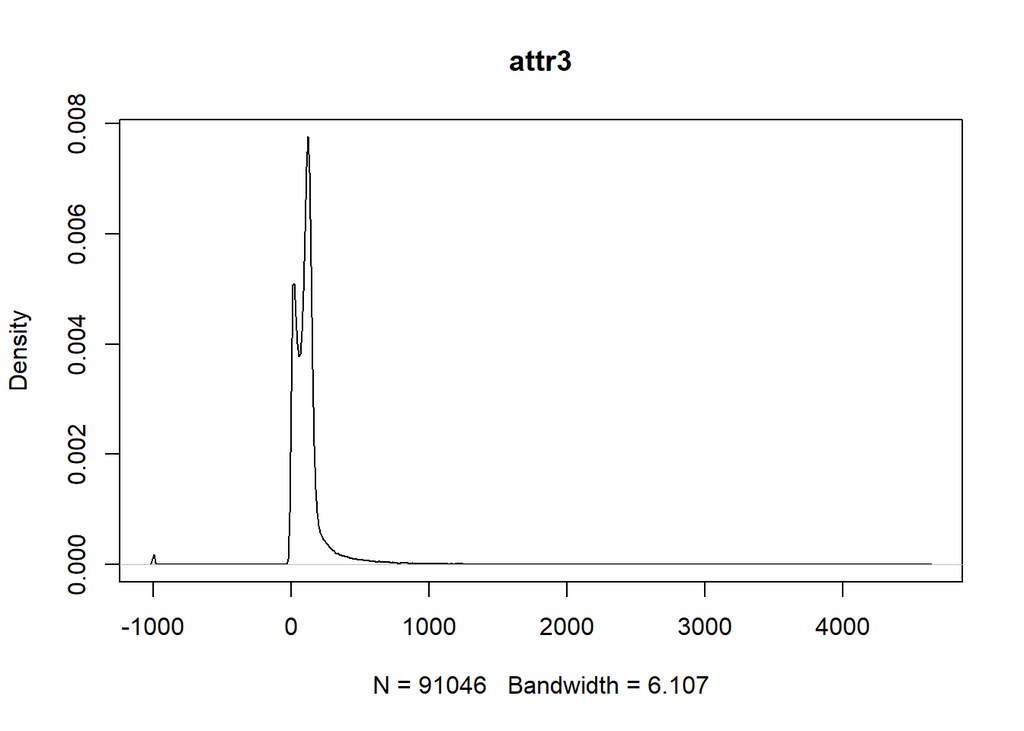

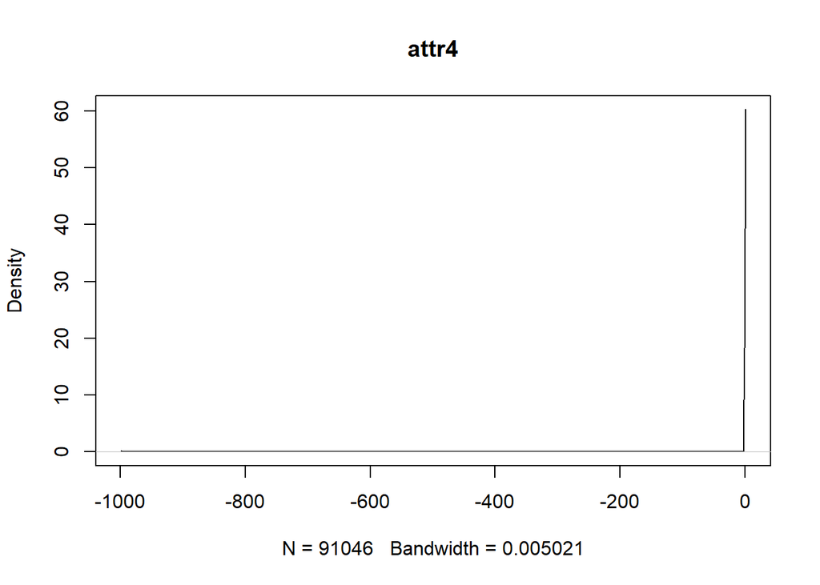

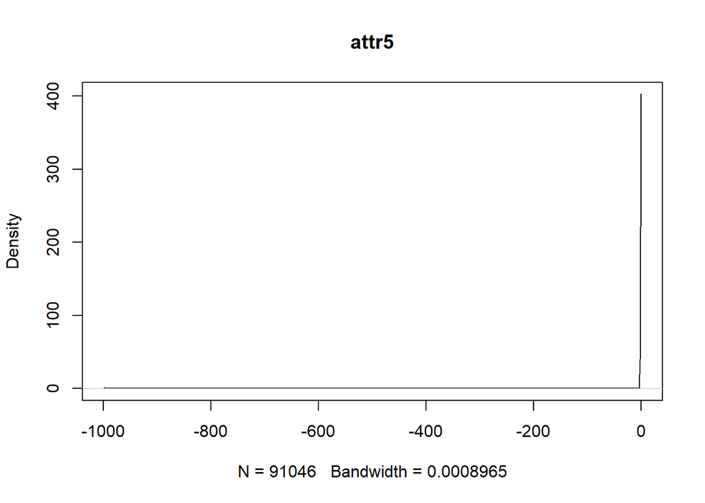

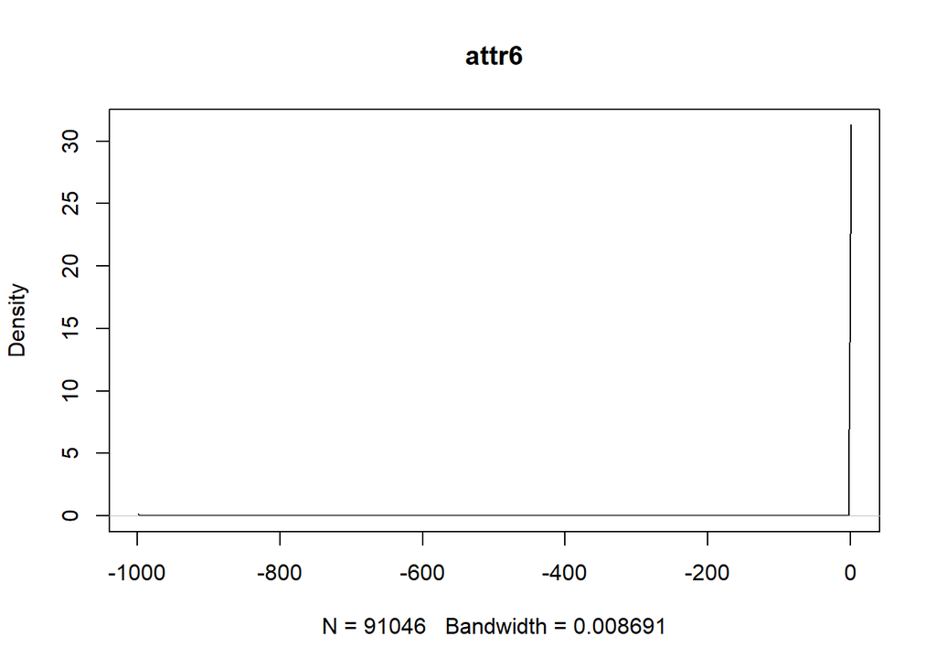

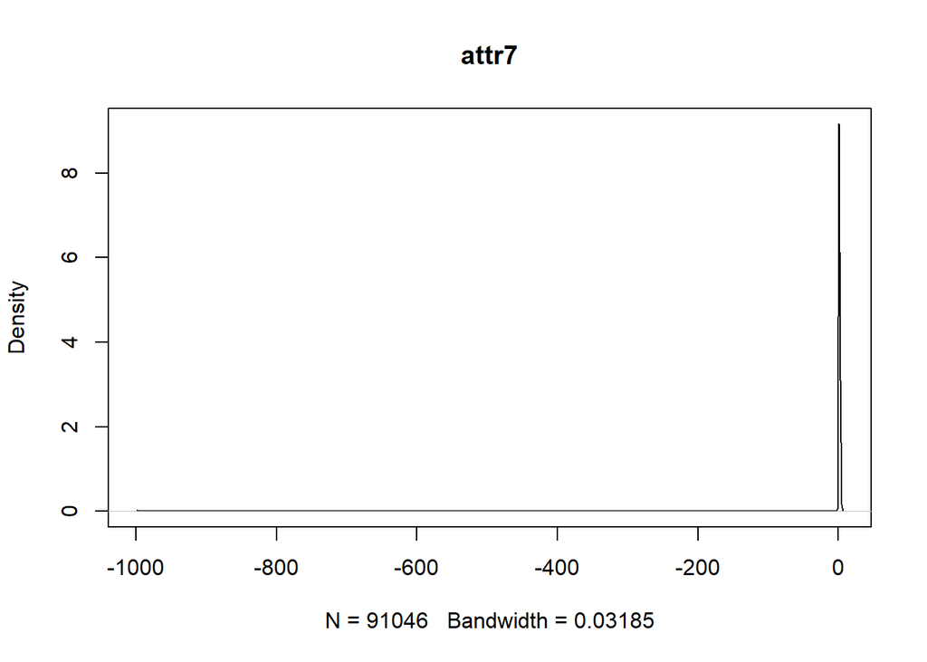

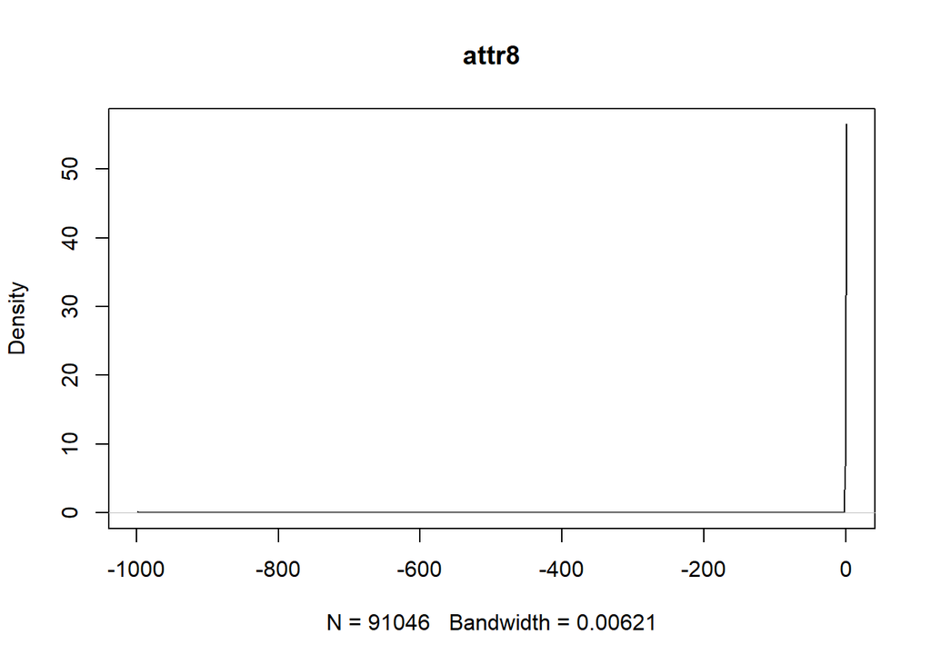

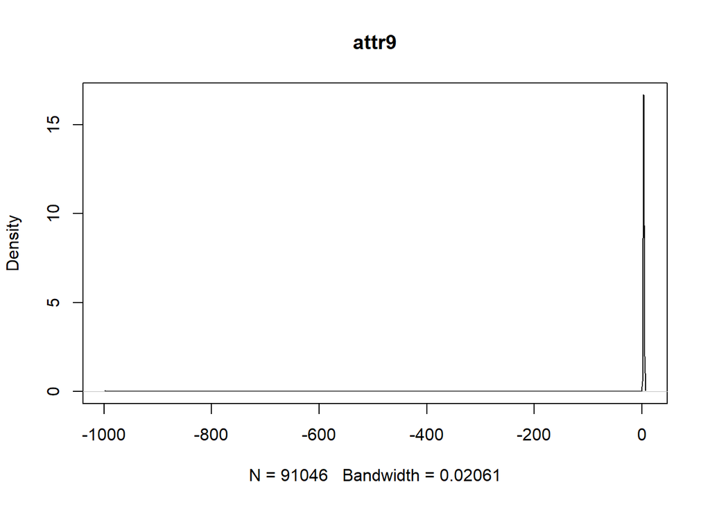

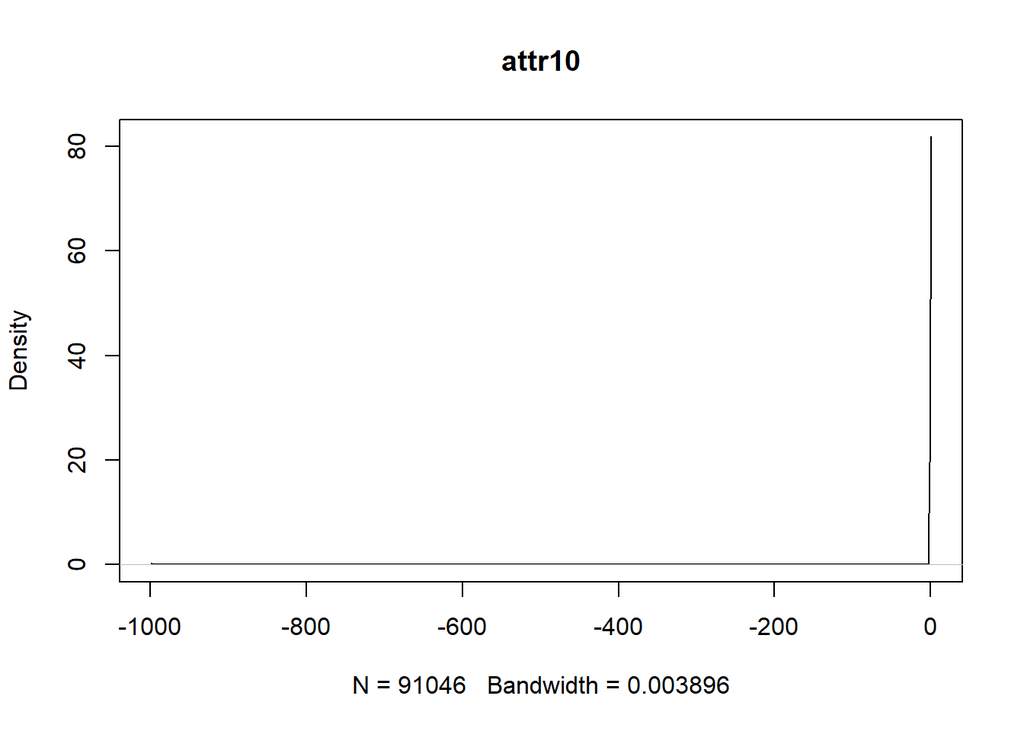

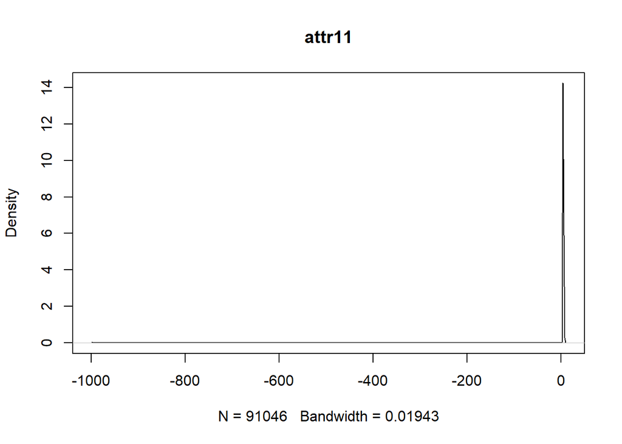

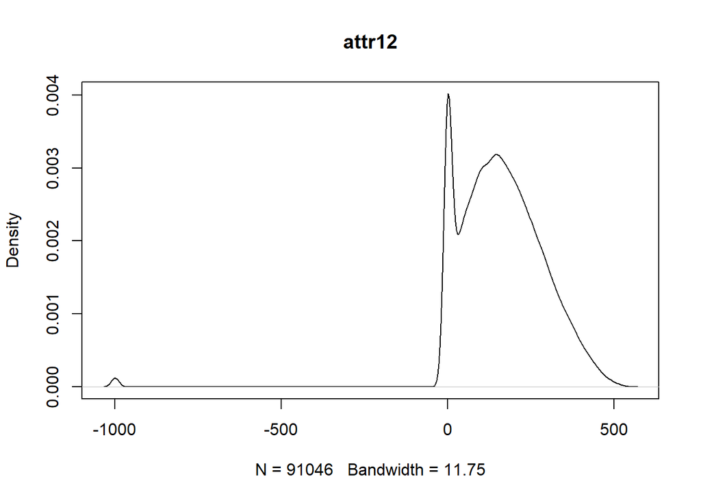

[38 more figures not shown]

```r
# Density plot for each attribute
# par(mfrow=c(dispRow,dispCol))
for(i in 1:totAttr) {
    plot(density(x_train[,i]), main=names(x_train)[i])
}
```

#### 2.b.ii) Multivariate plots to better understand the relationships between attributes

```r
# Scatterplot matrix colored by class
# pairs(targetVar~., data=xy_train, col=xy_train$targetVar)
```

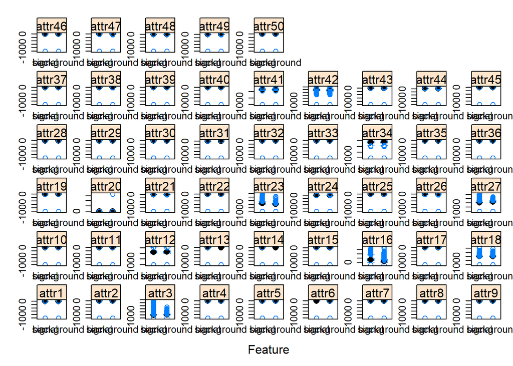

```r
# Box and whisker plots for each attribute by class
scales <- list(x=list(relation="free"), y=list(relation="free"))
featurePlot(x=x_train, y=y_train, plot="box", scales=scales)
```

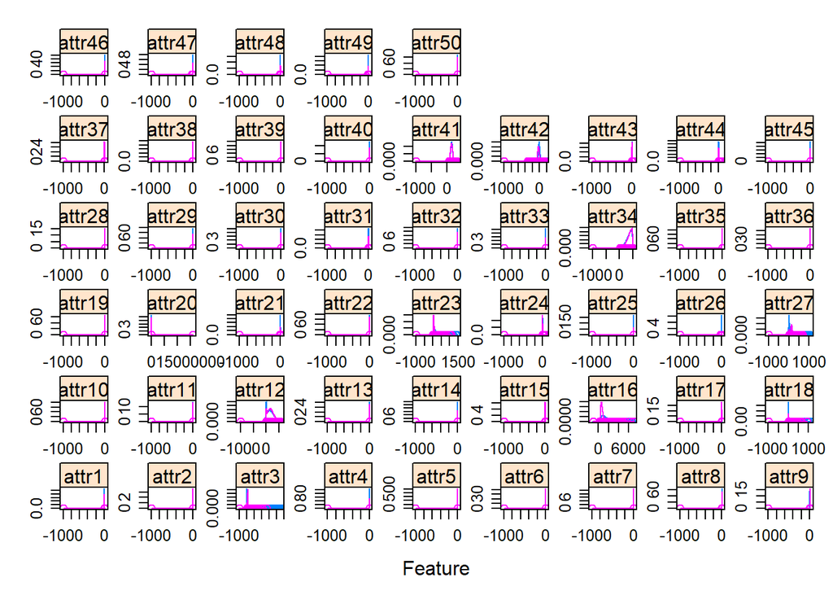

```r
# Density plots for each attribute by class value
featurePlot(x=x_train, y=y_train, plot="density", scales=scales)
```

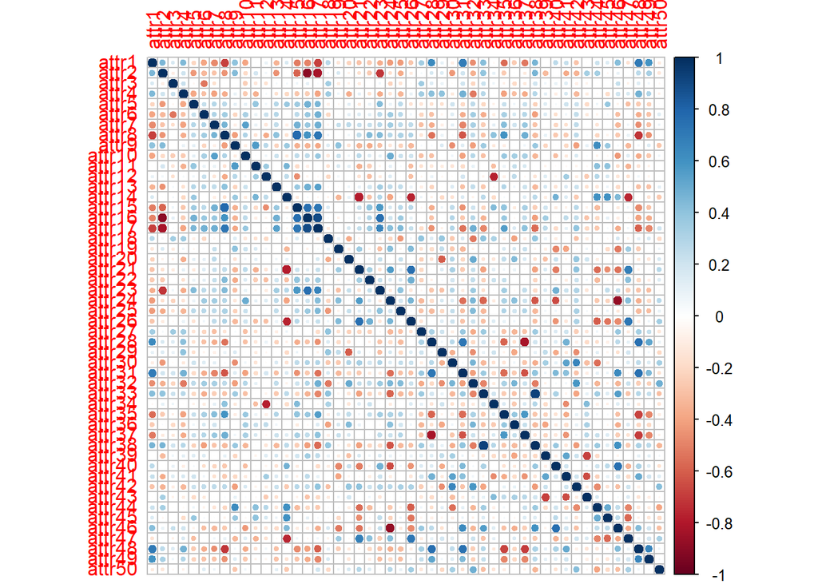

```r
# Correlation plot
correlations <- cor(x_train, method = "spearman")
corrplot(correlations, method="circle")
```

```r
email_notify(paste("Data Summarization and Visualization completed!",date()))
```

```
## [1] "Java-Object{org.apache.commons.mail.SimpleEmail@6d7b4f4c}"
```

## 3. Prepare Data

Some dataset may require additional preparation activities that will best exposes the structure of the problem and the relationships between the input attributes and the output variable. Some data-prep tasks might include:

- Cleaning data by removing duplicates, marking missing values and even imputing missing values.
- Feature selection where redundant features may be removed.
- Data transforms where attributes are scaled or redistributed in order to best expose the structure of the problem later to learning algorithms.

```r
email_notify(paste("Data Cleaning and Transformation has begun!",date()))
```

```
## [1] "Java-Object{org.apache.commons.mail.SimpleEmail@63753b6d}"
```

### 3.a) Data Cleaning

```r
# Not applicable for this iteration of the project.
```

### 3.b) Feature Selection

```r
# Sample code for performing feature selection by ranking the attributes' importance.
startTimeModule <- proc.time()
set.seed(seedNum)
library(gbm)
model_fs <- train(targetVar~., data=xy_train, method="gbm", preProcess="scale", trControl=control, verbose=F)
rankedImportance <- varImp(model_fs, scale=FALSE)
print(rankedImportance)
```

```
## gbm variable importance
##
##   only 20 most important variables shown (out of 50)
##
##        Overall
## attr17 8904.71
## attr1  8768.98
## attr3  3797.60
## attr32 2641.49
## attr27 1831.28
## attr23 1750.97
## attr13 1573.84
## attr26  860.16
## attr16  845.77
## attr4   749.01
## attr6   614.35
## attr2   468.71
## attr21  393.34
## attr18  319.38
## attr7   316.79
## attr28  203.95
## attr12  178.32
## attr25  148.90
## attr30  136.09
## attr37   90.33
```

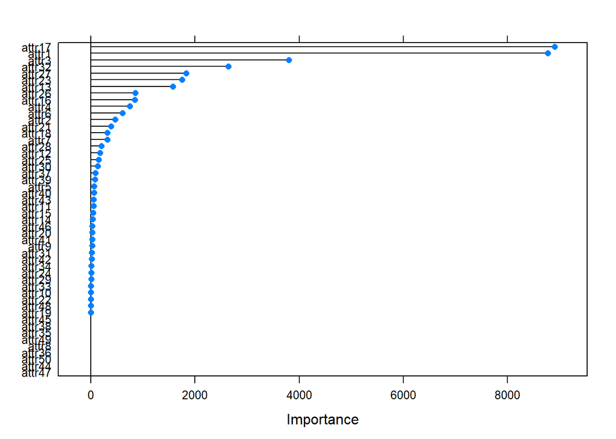

```r
plot(rankedImportance)
```

```r
# Set the importance threshold and calculate the list of attributes that don't contribute to the importance threshold
maxThreshold <- 0.99
rankedAttributes <- rankedImportance$importance
rankedAttributes <- rankedAttributes[order(-rankedAttributes$Overall),,drop=FALSE]
totalWeight <- sum(rankedAttributes)
i <- 1
accumWeight <- 0
exit_now <- FALSE
while ((i <= totAttr) & !exit_now) {
  accumWeight = accumWeight + rankedAttributes[i,]
  if ((accumWeight/totalWeight) >= maxThreshold) {
    exit_now <- TRUE
  } else {
    i <- i + 1
  }
}
lowImportance <- rankedAttributes[(i+1):(totAttr),,drop=FALSE]
lowAttributes <- rownames(lowImportance)
cat('Number of attributes contributed to the importance threshold:',i,"\n")
```

```
## Number of attributes contributed to the importance threshold: 25
```

```r
cat('Number of attributes found to be of low importance:',length(lowAttributes))
```

```
## Number of attributes found to be of low importance: 25
```

```r
# Removing the unselected attributes from the training and validation dataframes
xy_train <- xy_train[, !(names(xy_train) %in% lowAttributes)]
xy_test <- xy_test[, !(names(xy_test) %in% lowAttributes)]
```

### 3.c) Data Transforms

```r
# Not applicable for this iteration of the project.
```

### 3.d) Display the Final Dataset for Model-Building

```r
dim(xy_train)
```

```
## [1] 91046    26
```

```r
sapply(xy_train, class)
```

```
##     attr1     attr2     attr3     attr4     attr5     attr6     attr7
## "numeric" "numeric" "numeric" "numeric" "numeric" "numeric" "numeric"
##    attr11    attr12    attr13    attr16    attr17    attr18    attr21
## "numeric" "numeric" "numeric" "numeric" "numeric" "numeric" "numeric"
##    attr23    attr25    attr26    attr27    attr28    attr30    attr32
## "numeric" "numeric" "numeric" "numeric" "numeric" "numeric" "numeric"
##    attr37    attr39    attr40    attr43 targetVar
## "numeric" "numeric" "numeric" "numeric"  "factor"
```

```r
email_notify(paste("Data Cleaning and Transformation completed!",date()))
```

```
## [1] "Java-Object{org.apache.commons.mail.SimpleEmail@eec5a4a}"
```

```r
proc.time()-startTimeScript
```

```
##    user  system elapsed
## 1186.10  592.63 1791.92
```

## 4. Model and Evaluate Algorithms

After the data-prep, we next work on finding a workable model by evaluating a subset of machine learning algorithms that are good at exploiting the structure of the training. The typical evaluation tasks include:

- Defining test options such as cross validation and the evaluation metric to use.
- Spot checking a suite of linear and nonlinear machine learning algorithms.
- Comparing the estimated accuracy of algorithms.

For this project, we will evaluate one linear, two non-linear, and three ensemble algorithms:

Linear Algorithm: Logistic Regression

Non-Linear Algorithms: Decision Trees (CART) and k-Nearest Neighbors

Ensemble Algorithms: Bagged CART, Random Forest, and Stochastic Gradient Boosting

The random number seed is reset before each run to ensure that the evaluation of each algorithm is performed using the same data splits. It ensures the results are directly comparable.

### 4.a) Generate models using linear algorithms

```r
# Logistic Regression (Classification)
email_notify(paste("Linear Regression modeling has begun!",date()))
```

```
## [1] "Java-Object{org.apache.commons.mail.SimpleEmail@4b4523f8}"
```

```r
startTimeModule <- proc.time()
set.seed(seedNum)
fit.glm <- train(targetVar~., data=xy_train, method="glm", metric=metricTarget, trControl=control)
print(fit.glm)
```

```
## Generalized Linear Model
##
## 91046 samples
##    25 predictor
##     2 classes: 'signal', 'background'
##
## No pre-processing
## Resampling: Cross-Validated (10 fold, repeated 1 times)
## Summary of sample sizes: 81942, 81942, 81941, 81942, 81941, 81941, ...
## Resampling results:
##
##   Accuracy   Kappa
##   0.9035322  0.7597188
```

```r
proc.time()-startTimeModule
```

```
##    user  system elapsed
##   66.42   29.08   14.08
```

```r
email_notify(paste("Linear Regression modeling completed!",date()))
```

```
## [1] "Java-Object{org.apache.commons.mail.SimpleEmail@67b92f0a}"
```

### 4.b) Generate models using nonlinear algorithms

```r
# Decision Tree - CART (Regression/Classification)
email_notify(paste("Decision Tree modeling has begun!",date()))
```

```
## [1] "Java-Object{org.apache.commons.mail.SimpleEmail@887af79}"
```

```r
startTimeModule <- proc.time()
set.seed(seedNum)
fit.cart <- train(targetVar~., data=xy_train, method="rpart", metric=metricTarget, trControl=control)
print(fit.cart)
```

```
## CART
##
## 91046 samples
##    25 predictor
##     2 classes: 'signal', 'background'
##
## No pre-processing
## Resampling: Cross-Validated (10 fold, repeated 1 times)
## Summary of sample sizes: 81942, 81942, 81941, 81942, 81941, 81941, ...
## Resampling results across tuning parameters:
##
##   cp          Accuracy   Kappa
##   0.01953033  0.8606090  0.6580806
##   0.04293542  0.8471104  0.6165905
##   0.39953033  0.8082627  0.4390095
##
## Accuracy was used to select the optimal model using the largest value.
## The final value used for the model was cp = 0.01953033.
```

```r
proc.time()-startTimeModule
```

```
##    user  system elapsed
##   57.39    9.22   39.97
```

```r
email_notify(paste("Decision Tree modeling completed!",date()))
```

```
## [1] "Java-Object{org.apache.commons.mail.SimpleEmail@23e028a9}"
```

```r
# k-Nearest Neighbors (Regression/Classification)
email_notify(paste("k-Nearest Neighbors modeling has begun!",date()))
```

```
## [1] "Java-Object{org.apache.commons.mail.SimpleEmail@3701eaf6}"
```

```r
startTimeModule <- proc.time()
set.seed(seedNum)
fit.knn <- train(targetVar~., data=xy_train, method="knn", metric=metricTarget, trControl=control)
print(fit.knn)
```

```
## k-Nearest Neighbors
##
## 91046 samples
##    25 predictor
##     2 classes: 'signal', 'background'
##
## No pre-processing
## Resampling: Cross-Validated (10 fold, repeated 1 times)
## Summary of sample sizes: 81942, 81942, 81941, 81942, 81941, 81941, ...
## Resampling results across tuning parameters:
##
##   k  Accuracy   Kappa
##   5  0.8718449  0.6821719
##   7  0.8753486  0.6905468
##   9  0.8771169  0.6946139
##
## Accuracy was used to select the optimal model using the largest value.
## The final value used for the model was k = 9.
```

```r
proc.time()-startTimeModule
```

```
##    user  system elapsed
## 1014.61    0.50 1015.35
```

```r
email_notify(paste("k-Nearest Neighbors modeling completed!",date()))
```

```
## [1] "Java-Object{org.apache.commons.mail.SimpleEmail@32709393}"
```

### 4.c) Generate models using ensemble algorithms

In this section, we will explore the use and tuning of ensemble algorithms to see whether we can improve the results.

```r
# Bagged CART (Regression/Classification)
email_notify(paste("Bagged CART modeling has begun!",date()))
```

```
## [1] "Java-Object{org.apache.commons.mail.SimpleEmail@6321e813}"
```

```r
startTimeModule <- proc.time()
set.seed(seedNum)
fit.bagcart <- train(targetVar~., data=xy_train, method="treebag", metric=metricTarget, trControl=control)
print(fit.bagcart)
```

```
## Bagged CART
##
## 91046 samples
##    25 predictor
##     2 classes: 'signal', 'background'
##
## No pre-processing
## Resampling: Cross-Validated (10 fold, repeated 1 times)
## Summary of sample sizes: 81942, 81942, 81941, 81942, 81941, 81941, ...
## Resampling results:
##
##   Accuracy   Kappa
##   0.9299584  0.8262204
```

```r
proc.time()-startTimeModule
```

```
##    user  system elapsed
## 1345.31  251.39  939.50
```

```r
email_notify(paste("Bagged CART modeling completed!",date()))
```

```
## [1] "Java-Object{org.apache.commons.mail.SimpleEmail@30b8a058}"
```

```r
# Random Forest (Regression/Classification)
email_notify(paste("Random Forest modeling has begun!",date()))
```

```
## [1] "Java-Object{org.apache.commons.mail.SimpleEmail@6c49835d}"
```

```r
startTimeModule <- proc.time()
set.seed(seedNum)
fit.rf <- train(targetVar~., data=xy_train, method="rf", metric=metricTarget, trControl=control)
print(fit.rf)
```

```
## Random Forest
##
## 91046 samples
##    25 predictor
##     2 classes: 'signal', 'background'
##
## No pre-processing
## Resampling: Cross-Validated (10 fold, repeated 1 times)
## Summary of sample sizes: 81942, 81942, 81941, 81942, 81941, 81941, ...
## Resampling results across tuning parameters:
##
##   mtry  Accuracy   Kappa
##    2    0.9311995  0.8286205
##   13    0.9351096  0.8390727
##   25    0.9332974  0.8345279
##
## Accuracy was used to select the optimal model using the largest value.
## The final value used for the model was mtry = 13.
```

```r
proc.time()-startTimeModule
```

```
##    user  system elapsed
## 8127.42   42.57 8182.00
```

```r
email_notify(paste("Random Forest modeling completed!",date()))
```

```
## [1] "Java-Object{org.apache.commons.mail.SimpleEmail@48503868}"
```

```r
# Stochastic Gradient Boosting (Regression/Classification)
email_notify(paste("Stochastic Gradient Boosting modeling has begun!",date()))
```

```
## [1] "Java-Object{org.apache.commons.mail.SimpleEmail@396f6598}"
```

```r
startTimeModule <- proc.time()
set.seed(seedNum)
fit.gbm <- train(targetVar~., data=xy_train, method="gbm", metric=metricTarget, trControl=control, verbose=F)
print(fit.gbm)
```

```
## Stochastic Gradient Boosting
##
## 91046 samples
##    25 predictor
##     2 classes: 'signal', 'background'
##
## No pre-processing
## Resampling: Cross-Validated (10 fold, repeated 1 times)
## Summary of sample sizes: 81942, 81942, 81941, 81942, 81941, 81941, ...
## Resampling results across tuning parameters:
##
##   interaction.depth  n.trees  Accuracy   Kappa
##   1                   50      0.8775892  0.6793876
##   1                  100      0.8948772  0.7310675
##   1                  150      0.9032136  0.7548412
##   2                   50      0.8998308  0.7460044
##   2                  100      0.9124288  0.7809816
##   2                  150      0.9182720  0.7965298
##   3                   50      0.9066844  0.7648469
##   3                  100      0.9188760  0.7977823
##   3                  150      0.9235001  0.8099822
##
## Tuning parameter 'shrinkage' was held constant at a value of 0.1
##
## Tuning parameter 'n.minobsinnode' was held constant at a value of 10
## Accuracy was used to select the optimal model using the largest value.
## The final values used for the model were n.trees = 150,
##  interaction.depth = 3, shrinkage = 0.1 and n.minobsinnode = 10.
```

```r
proc.time()-startTimeModule
```

```
##    user  system elapsed
##  539.57    5.43  547.10
```

```r
email_notify(paste("Stochastic Gradient Boosting modeling completed!",date()))
```

```
## [1] "Java-Object{org.apache.commons.mail.SimpleEmail@15d0c81b}"
```

### 4.d) Compare baseline algorithms

```r
results <- resamples(list(LR=fit.glm, CART=fit.cart, kNN=fit.knn, BagCART=fit.bagcart, RF=fit.rf, GBM=fit.gbm))
summary(results)
```

```
##
## Call:
## summary.resamples(object = results)
##
## Models: LR, CART, kNN, BagCART, RF, GBM
## Number of resamples: 10
##
## Accuracy
##              Min.   1st Qu.    Median      Mean   3rd Qu.      Max. NA's
## LR      0.8977485 0.8998243 0.9040637 0.9035322 0.9056811 0.9105986    0
## CART    0.8519332 0.8552718 0.8607283 0.8606090 0.8664085 0.8687390    0
## kNN     0.8721582 0.8742036 0.8760503 0.8771169 0.8792696 0.8846787    0
## BagCART 0.9256452 0.9276966 0.9299247 0.9299584 0.9322625 0.9338825    0
## RF      0.9310269 0.9329141 0.9347575 0.9351096 0.9380011 0.9387150    0
## GBM     0.9173989 0.9206205 0.9237698 0.9235001 0.9266063 0.9283910    0
##
## Kappa
##              Min.   1st Qu.    Median      Mean   3rd Qu.      Max. NA's
## LR      0.7460224 0.7497608 0.7602503 0.7597188 0.7654611 0.7777713    0
## CART    0.6361530 0.6451477 0.6567356 0.6580806 0.6720519 0.6818579    0
## kNN     0.6827505 0.6874850 0.6911284 0.6946139 0.7002705 0.7136844    0
## BagCART 0.8155932 0.8204801 0.8258571 0.8262204 0.8320088 0.8362376    0
## RF      0.8292870 0.8328348 0.8381414 0.8390727 0.8463286 0.8481707    0
## GBM     0.7941467 0.8030452 0.8104074 0.8099822 0.8180465 0.8225513    0
```

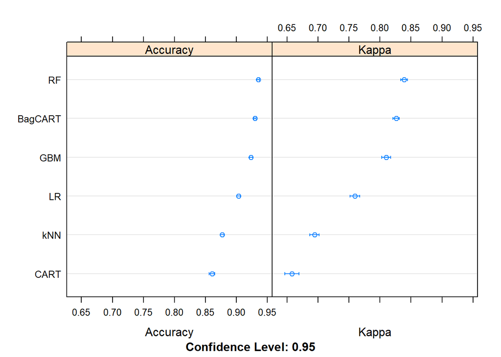

```r
dotplot(results)
```

```r
cat('The average accuracy from all models is:',
    mean(c(results$values$`LR~Accuracy`,results$values$`CART~Accuracy`,results$values$`kNN~Accuracy`,results$values$`BagCART~Accuracy`,results$values$`RF~Accuracy`,results$values$`GBM~Accuracy`)))
```

```
## The average accuracy from all models is: 0.904971
```

## 5. Improve Accuracy or Results

After we achieve a short list of machine learning algorithms with good level of accuracy, we can leverage ways to improve the accuracy of the models.

### 5.a) Algorithm Tuning

```r
# Tuning algorithm #1 - Stochastic Gradient Boosting
email_notify(paste("Algorithm #1 tuning has begun!",date()))
```

```
## [1] "Java-Object{org.apache.commons.mail.SimpleEmail@2833cc44}"
```

```r
startTimeModule <- proc.time()
set.seed(seedNum)
grid <- expand.grid(.n.trees=c(250,400,550,700), .shrinkage=0.1, .interaction.depth=3, .n.minobsinnode=10)
fit.final1 <- train(targetVar~., data=xy_train, method="gbm", metric=metricTarget, tuneGrid=grid, trControl=control, verbose=F)
print(fit.final1)
```

```
## Stochastic Gradient Boosting
##
## 91046 samples
##    25 predictor
##     2 classes: 'signal', 'background'
##
## No pre-processing
## Resampling: Cross-Validated (10 fold, repeated 1 times)
## Summary of sample sizes: 81942, 81942, 81941, 81942, 81941, 81941, ...
## Resampling results across tuning parameters:
##
##   n.trees  Accuracy   Kappa
##   250      0.9281900  0.8220854
##   400      0.9313972  0.8300848
##   550      0.9337477  0.8359886
##   700      0.9348021  0.8386923
##
## Tuning parameter 'interaction.depth' was held constant at a value of
##  3
## Tuning parameter 'shrinkage' was held constant at a value of 0.1
##
## Tuning parameter 'n.minobsinnode' was held constant at a value of 10
## Accuracy was used to select the optimal model using the largest value.
## The final values used for the model were n.trees = 700,
##  interaction.depth = 3, shrinkage = 0.1 and n.minobsinnode = 10.
```

```r
proc.time()-startTimeModule
```

```
##    user  system elapsed
## 1161.82    1.75 1167.63
```

```r
email_notify(paste("Algorithm #1 tuning completed!",date()))
```

```
## [1] "Java-Object{org.apache.commons.mail.SimpleEmail@59e5ddf}"
```

```r
# Tuning algorithm #2 - Random Forest
email_notify(paste("Algorithm #2 tuning has begun!",date()))
```

```
## [1] "Java-Object{org.apache.commons.mail.SimpleEmail@6ee52dcd}"
```

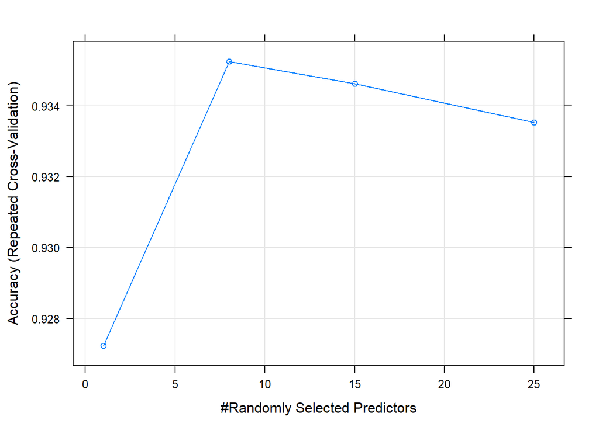

```r
startTimeModule <- proc.time()
set.seed(seedNum)
grid <- expand.grid(mtry=c(1,8,15,25))
fit.final2 <- train(targetVar~., data=xy_train, method="rf", metric=metricTarget, tuneGrid=grid, trControl=control)
plot(fit.final2)
```

```r
print(fit.final2)
```

```
## Random Forest
##
## 91046 samples
##    25 predictor
##     2 classes: 'signal', 'background'
##
## No pre-processing
## Resampling: Cross-Validated (10 fold, repeated 1 times)
## Summary of sample sizes: 81942, 81942, 81941, 81942, 81941, 81941, ...
## Resampling results across tuning parameters:
##
##   mtry  Accuracy   Kappa
##    1    0.9272235  0.8177561
##    8    0.9352634  0.8394297
##   15    0.9346264  0.8378741
##   25    0.9335390  0.8351225
##
## Accuracy was used to select the optimal model using the largest value.
## The final value used for the model was mtry = 8.
```

```r
proc.time()-startTimeModule
```

```
##     user   system  elapsed
## 10274.64    54.81 10354.67
```

```r
email_notify(paste("Algorithm #2 tuning completed!",date()))
```

```
## [1] "Java-Object{org.apache.commons.mail.SimpleEmail@528931cf}"
```

### 5.d) Compare Algorithms After Tuning

```r
results <- resamples(list(GBM=fit.final1, RF=fit.final2))
summary(results)
```

```
##
## Call:
## summary.resamples(object = results)
##
## Models: GBM, RF
## Number of resamples: 10
##
## Accuracy
##          Min.   1st Qu.    Median      Mean   3rd Qu.      Max. NA's
## GBM 0.9292619 0.9318724 0.9348089 0.9348021 0.9372323 0.9402526    0
## RF  0.9319055 0.9331063 0.9353066 0.9352634 0.9371225 0.9398133    0
##
## Kappa
##          Min.   1st Qu.    Median      Mean   3rd Qu.      Max. NA's
## GBM 0.8246792 0.8313649 0.8384367 0.8386923 0.8451962 0.8526835    0
## RF  0.8313008 0.8337422 0.8396568 0.8394297 0.8443825 0.8507848    0
```

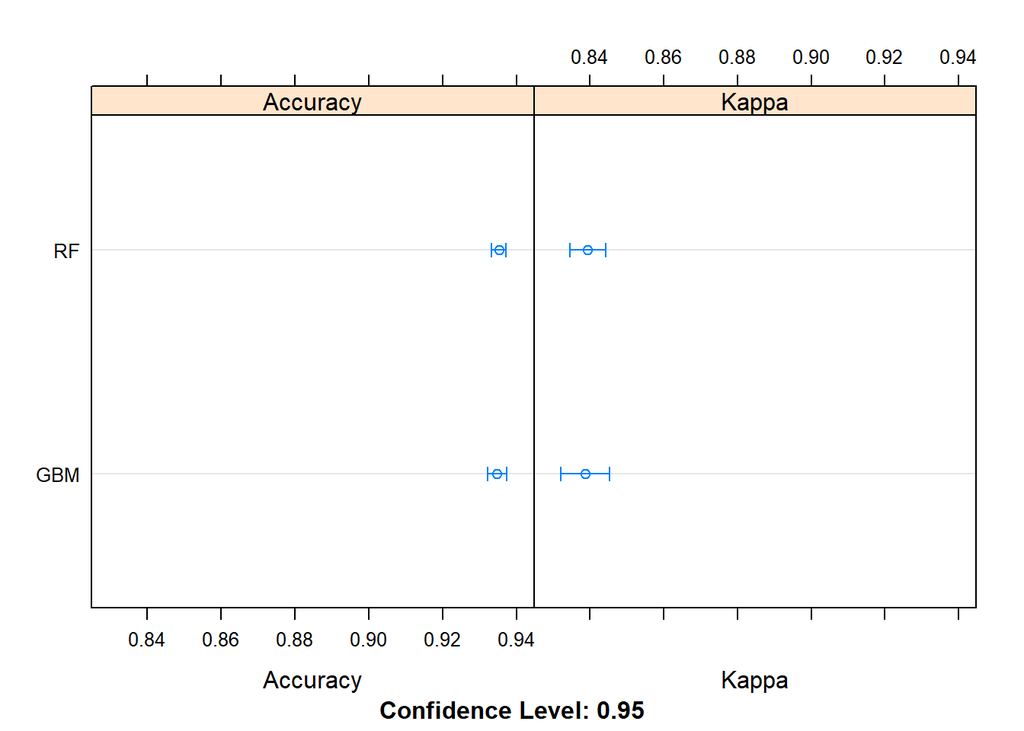

```r
dotplot(results)
```

## 6. Finalize Model and Present Results

Once we have narrow down to a model that we believe can make accurate predictions on unseen data, we are ready to finalize it. Finalizing a model may involve sub-tasks such as:

- Using an optimal model tuned to make predictions on unseen data.
- Creating a standalone model using the tuned parameters
- Saving an optimal model to file for later use.

```r
email_notify(paste("Model Validation and Final Model Creation has begun!",date()))
```

```
## [1] "Java-Object{org.apache.commons.mail.SimpleEmail@34c4973}"
```

### 6.a) Predictions on validation dataset

```r
predictions <- predict(fit.final2, newdata=xy_test)
confusionMatrix(predictions, y_test)
```

```
## Confusion Matrix and Statistics
##
##             Reference
## Prediction   signal background
##   signal       9726       1220
##   background   1223      26849
##
##                Accuracy : 0.9374
##                  95% CI : (0.9349, 0.9398)
##     No Information Rate : 0.7194
##     P-Value [Acc > NIR] : <2e-16
##
##                   Kappa : 0.8449
##  Mcnemar's Test P-Value : 0.9677
##
##             Sensitivity : 0.8883
##             Specificity : 0.9565
##          Pos Pred Value : 0.8885
##          Neg Pred Value : 0.9564
##              Prevalence : 0.2806
##          Detection Rate : 0.2493
##    Detection Prevalence : 0.2805
##       Balanced Accuracy : 0.9224
##
##        'Positive' Class : signal
##
```

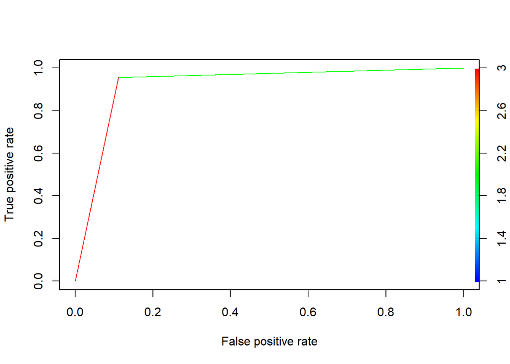

```r
pred <- prediction(as.numeric(predictions), as.numeric(y_test))
perf <- performance(pred, measure = "tpr", x.measure = "fpr")
plot(perf, colorize=TRUE)
```

```r
auc <- performance(pred, measure = "auc")
auc <- auc@y.values[[1]]
auc
```

```
## [1] 0.922418
```

### 6.b) Create standalone model on entire training dataset

```r
startTimeModule <- proc.time()
library(randomForest)
set.seed(seedNum)

# Combining the training and test datasets to form the complete dataset that will be used for training the final model
xy_complete <- rbind(xy_train, xy_test)

# Covert the target variable column to 0 and 1 for training the final GBM model
# names(xy_complete)[names(xy_complete)=='targetVar'] <- 'oldTarget'
# xy_complete$targetVar <- 0
# xy_complete$targetVar[xy_complete$oldTarget=="signal"] <- 1
# xy_complete$oldTarget <- NULL

finalModel <- randomForest(targetVar ~ ., data = xy_complete, mtry=8)
print(finalModel)
```

```
##
## Call:
##  randomForest(formula = targetVar ~ ., data = xy_complete, mtry = 8)
##                Type of random forest: classification
##                      Number of trees: 500
## No. of variables tried at each split: 8
##
##         OOB estimate of  error rate: 6.32%
## Confusion matrix:
##            signal background class.error
## signal      32332       4167  0.11416751
## background   4050      89515  0.04328542
```

```r
proc.time()-startTimeModule
```

```
##    user  system elapsed
##  389.18    1.06  393.36
```

### 6.c) Save model for later use

```r
#saveRDS(finalModel, "./finalModel_BinaryClass.rds")
```

```r
email_notify(paste("Model Validation and Final Model Creation Completed!",date()))
```

```
## [1] "Java-Object{org.apache.commons.mail.SimpleEmail@86be70a}"
```

```r
proc.time()-startTimeScript
```

```
##     user   system  elapsed
## 24178.02   991.80 24489.61
```